# IE 582 - Homework - 2

#### 2.2. Bet365

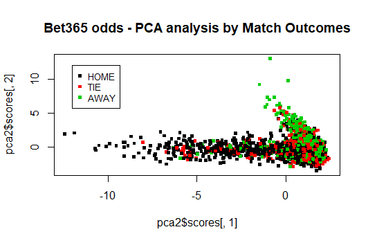

**Figure 33** - PCA analysis on Bet365 odds regarding game outcomes (Home,Tie, Away) - 2D representation.

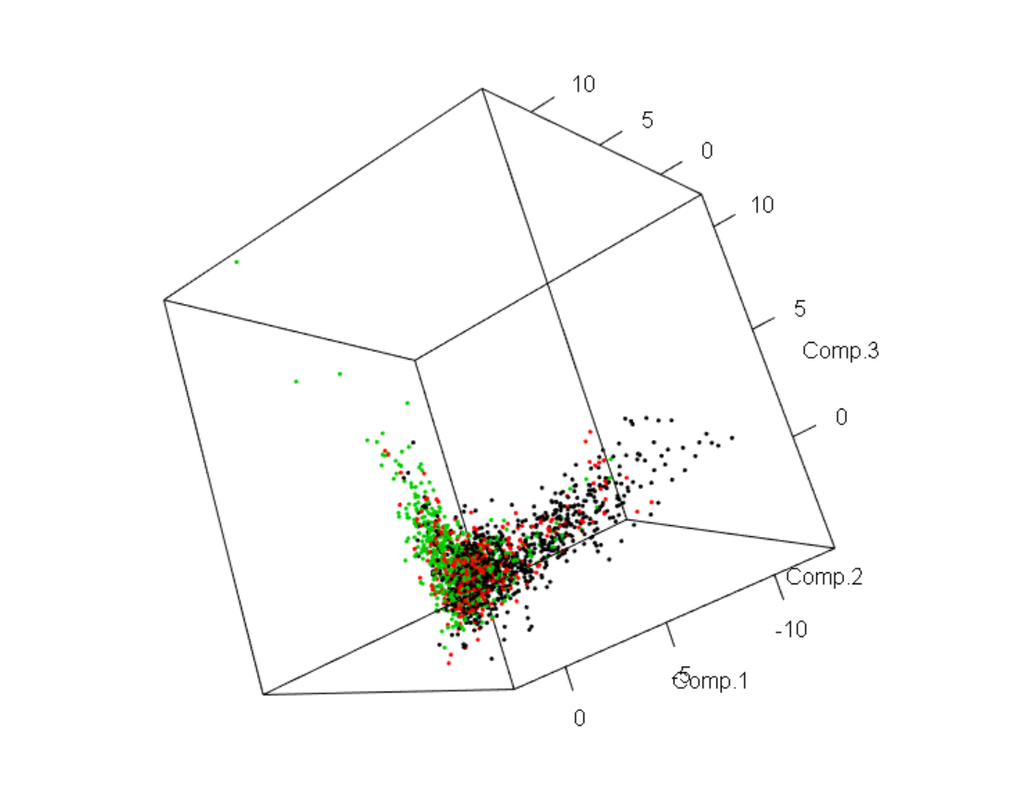

**Figure 34** - PCA analysis on Bet365 odds regarding game outcomes (Home,Tie, Away) - 3D representation.

#### 2.3. Bwin

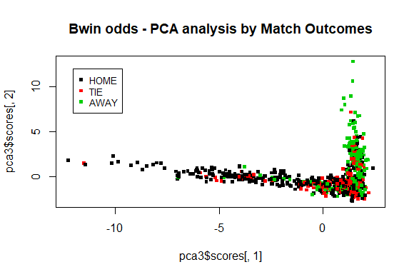

**Figure 35** - PCA analysis on Bwin odds regarding game outcomes (Home,Tie, Away) - 2D representation.

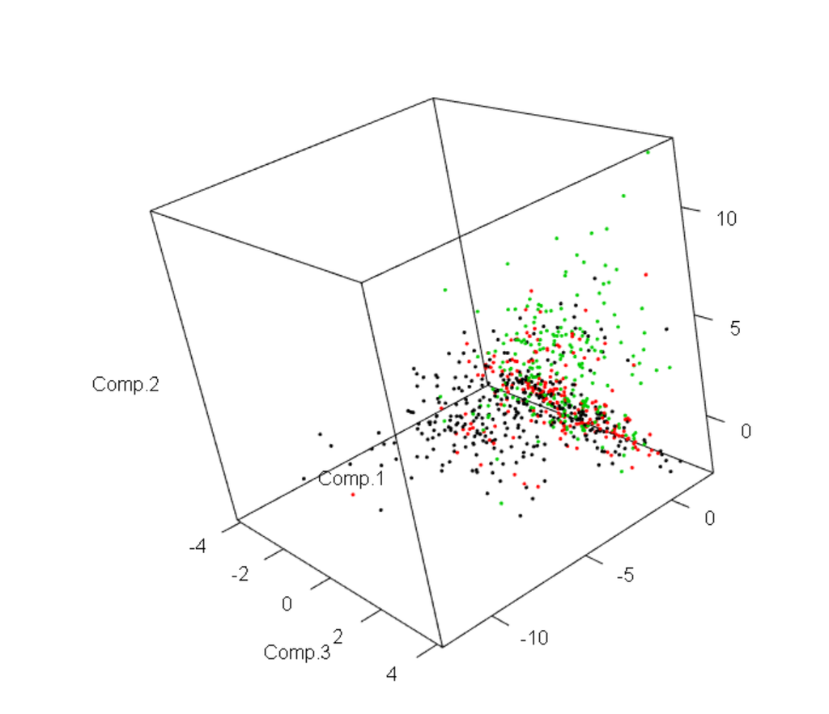

**Figure 36** - PCA analysis on Bwin odds regarding game outcomes (Home,Tie, Away) - 3D representation.

#### 2.4. Youwin

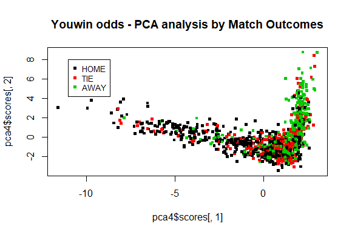

**Figure 37** - PCA analysis on Youwin odds regarding game outcomes (Home,Tie, Away) - 2D representation.

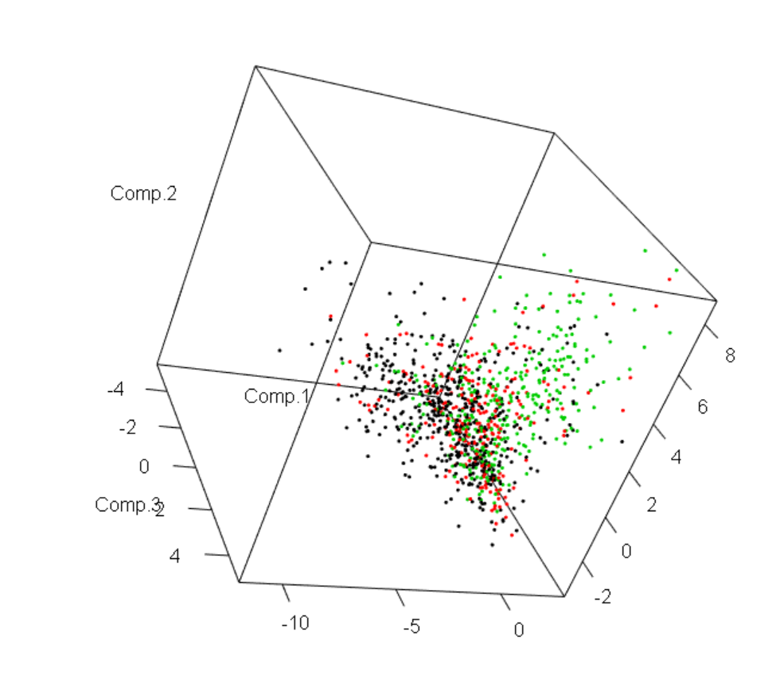

**Figure 38** - PCA analysis on Youwin odds regarding game outcomes (Home,Tie, Away) - 3D representation.

#### 2.4. ComeOn

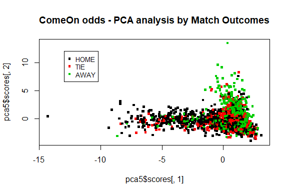

**Figure 39** - PCA analysis on ComeOn odds regarding game outcomes (Home,Tie, Away) - 2D representation.

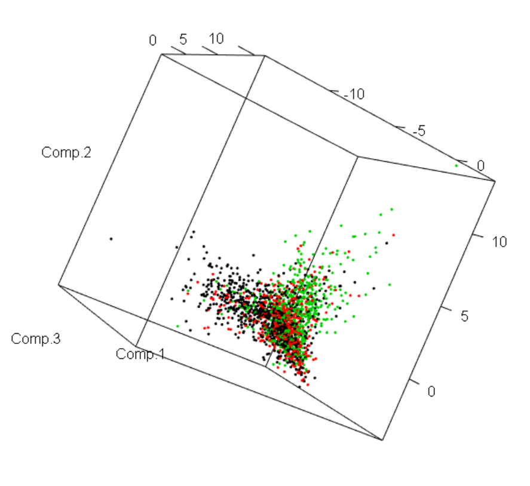

**Figure 40** - PCA analysis on ComeOn odds regarding game outcomes (Home,Tie, Away) - 3D representation.

# 3. Task 3

In this task, certain image operations are performed.

## 3.1. Read & Display the Image

First, using jpeg package, image is read and displayed via rasterImage function. The image of Mona Lisais chosen and given in **Figure 41**. The original image is in 512 x 512 pixels size.

[figure not shown]

**Figure 41** - The original image in the size of 512x512.

## 3.2. Color Channels of the Image

The image stores the color channels of red, green, and blue (RGB type). In this task, three color channels are extracted and given in **Figure 42**.

[figure not shown]

**Figure 42** - RGB color channels of the original image.

## 3.2. Creating the Noisy Image & Its Color Channels

In order to create a noisy image, uniformly distributed (in 0-0.1 range) noise is added to the original image. The pixel value higher than 1 are assumed as 1. Noisy image is shown in **Figure 43**.

[figure not shown]

**Figure 43** - The noisy image in the size of 512x512.

Similar to previous color channel extraction, R, G, and B color channels of the noisy image are obtained as in **Figure 44**.

[figure not shown]

**Figure 44** - RGB color channels of the noisy image.

## 3.3. Grayscaling the Noisy Image

Here, the noisy image is converted to grayscale image. In order to perform grayscale transformation, average of the color components is taken and normalized. Grayscale image of the colored noisy image can be seen in **Figure 45**.

[figure not shown]

**Figure 45** - Grayscale of the noisy image.

## 3.4. Resizing the Noisy Image

Since, PCA calculations will take too long on 512 x 512 pixels image, the image is resized as 200 x 200 pixels via custom-made resize function. The resized, grayscaled, noisy image is given in **Figure 46**. As can be see, resolution of the image is quite worsened.

[figure not shown]

**Figure 46** - Grayscaled & noisy image in the size of 200x200.

## 3.5. PCA Analysis on the Noisy Image

As described in the Homework, for the image on **Figure 46**, 198*198 patches are created as 3 by 3 patches. Then, PCA analysis on patches is performed.

The given PCA plot in **Figure 47** shows how each component in PCA explains the image. As can be seen, the first principle component explain the whole image quite well.

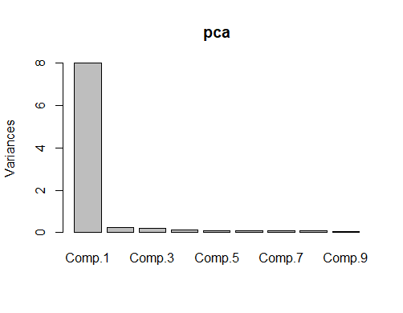

First 3 PCs are given in the **Figures 48-50**. It can be seen obviously that first PC is quite similar to the image, however second and third PCs are weak in representing the image. This is an expected result regarding the proportion of the variances of PC1, PC2, and PC3 changing as 88.6%, 2.9%, and 2.2%, respectively.

[figure not shown]

**Figure 48** - Reconstructed image from the PCA analysis using the PC 1.

[figure not shown]

**Figure 49** - Reconstructed image from the PCA analysis using the PC 2.

[figure not shown]

**Figure 50** - Reconstructed image from the PCA analysis using the PC 3.

# 4. Appendix

## 4.1. Codes of Task 1.a

## 4.1.1. Codes of Task 1.a - Pinnacle

```r
#include=TRUE writes the code on document
#eval=FALSE doesn't run the code during knitting
require(data.table)
require(anytime)
#require(dplyr)
#require(plotly)

#read data
matches = readRDS("C:/Users/09172/Desktop/df9b1196-e3cf-4cc7-9159-f236fe738215_matches.rds")
odd_details = readRDS("C:/Users/09172/Desktop/df9b1196-e3cf-4cc7-9159-f236fe738215_odd_details.rds")

data.table(matches)
data.table(odd_details)

matches=unique(matches)
odd_details =unique(odd_details)

matches[,type:=NULL] #deleted since all are soccer

#filter na scores
matches[is.na(score)]

#omit the rows with score = NA & divide the score into 2
matches_played = na.omit(matches,cols = "score")
matches_played[,c("score1","score2"):=tstrsplit(score,':')]

#add the scores up
matches_played[,totscore:= (as.numeric(score1)+as.numeric(score2))]
matches_played[,IsOver:=as.numeric(totscore>2)]
match_scores = matches_played[,c("leagueId","home", "away","score","date","score1","score2"):=NULL]

## PINNACLE
data_1 =odd_details[bookmaker=='Pinnacle']
# data_x =odd_details[bookmaker=='Pinnacle'& betType=='dc']

#order data in ascending date
odds_1=data_1[order(matchId,oddtype,bookmaker,date)]
# ou bets are evaluated separately
odds_1=odds_1[betType!='ou']
# only total handicap == 2.5 is taken into account
odds_2.5_1 =data_1[totalhandicap=='2.5']

#final odds were taken into account

odds_final_1=odds_1[,list(final_odd=odd[.N]),
                    by=list(matchId,oddtype,bookmaker)]
wide_odds_final_1=dcast(odds_final_1,
                        matchId~oddtype+bookmaker,
                        value.var='final_odd')

odds_2.5_final_1=odds_2.5_1[,list(final_odd=odd[.N]),
                            by=list(matchId,oddtype,bookmaker)]

wide_odds_2.5_final_1=dcast(odds_2.5_final_1,
                            matchId~oddtype+bookmaker,
                            value.var='final_odd')

merged_1=merge(wide_odds_final_1,wide_odds_2.5_final_1,by='matchId')
merged_1=merged_1[complete.cases(merged_1)]

merged_all_1=merge(merged_1,match_scores,by='matchId')


#PCA ANALYSIS
pca=princomp(merged_all_1[,2:8],cor = TRUE)
plot(pca, main = 'Pinnacle odds - PCA analysis')

str(pca)
summary(pca,loadings=T)

# #first component
# barplot(pca$scores[,1])
#
# #second component
# barplot(pca$scores[,2])

biplot(pca,main="Pinnacle - PCA - Biplot")
plot(pca$scores[,1],pca$scores[,2],col=merged_all_1$IsOver+1,pch=".",cex=5,main = "Pinnacle - PCA Analysis - Over/Under 2.5")
legend(-7, 8, legend=c("UNDER 2.5", "OVER 2.5"),
       col=c(1, 2), pch=".", cex=0.8, pt.cex=5)

require(rgl)
#plot3d(pca$scores[,1:3], col=merged_all_1$totscore+1)
plot3d(pca$scores[,1:3], col=merged_all_1$IsOver+1)

summary(pca$scores)
cor(pca$scores)

summary(merged_1[,2:8])
cor(merged_1[,2:8])
options(max.print = 100)

# MDS
#MANHATTAN DISTANCE
distance.matrix_m <- dist(scale((merged_1[,2:8]), center=TRUE, scale=TRUE),
                          method="manhattan")

## do the MDS math (this is basically eigen value decomposition)
mds.stuff_m <- cmdscale(distance.matrix_m, eig=TRUE, x.ret=TRUE)

## calculate the percentage of variation that each MDS axis accounts for...
mds.var.per_m <- round(mds.stuff_m$eig/sum(mds.stuff_m$eig)*100, 1)
mds.var.per_m

## now make a fancy looking plot that shows the MDS axes and the variation:
mds.values_m <- mds.stuff_m$points
plot(mds.values_m[,1],mds.values_m[,2],xlab='', ylab='',col=1, pch='.',cex=5, main = "Pinnacle - MDS plot using Manhattan distance")

# distances_e=dist(merged_1[,2:8], method = "euclidean", diag = TRUE, upper = TRUE)
# distances_e[is.na(distances_e)]=0
# mds_e=cmdscale(distances_e,eig=TRUE)
# plot(mds_e$points[,1],mds_e$points[,2],main='',xlab='', ylab='',col=1)
#
#  x=sum(mds_e$eig[1])/sum(mds_e$eig)
#
# euclideanMDS=dist(mds)
# sum((as.matrix(euclideanMDS)-as.matrix(distances))^2)

distance.matrix <- dist(scale((merged_1[,2:8]), center=TRUE, scale=TRUE),
                        method="euclidean")

## do the MDS math (this is basically eigen value decomposition)
mds.stuff <- cmdscale(distance.matrix, eig=TRUE, x.ret=TRUE)

## calculate the percentage of variation that each MDS axis accounts for...
mds.var.per <- round(mds.stuff$eig/sum(mds.stuff$eig)*100, 1)
mds.var.per

## now make a fancy looking plot that shows the MDS axes and the variation:
mds.values <- mds.stuff$points
mds.data <- data.frame(X=mds.values[,1],
                       Y=mds.values[,2])
mds.data

plot(mds.values[,1],mds.values[,2],main='Pinnacle - MDS plot using Euclidean distance',xlab='', ylab='',pch='.', cex=5,col=1)
```

## 4.1.2. Codes of Task 1.a - Bet365

```r
#include=TRUE writes the code on document
#eval=FALSE doesn't run the code during knitting
require(data.table)
require(anytime)
#require(dplyr)
#require(plotly)

#read data
matches = readRDS("C:/Users/09172/Desktop/df9b1196-e3cf-4cc7-9159-f236fe738215_matches.rds")
odd_details = readRDS("C:/Users/09172/Desktop/df9b1196-e3cf-4cc7-9159-f236fe738215_odd_details.rds")

data.table(matches)
data.table(odd_details)

matches=unique(matches)
odd_details =unique(odd_details)

matches[,type:=NULL] #deleted since all are soccer

#filter na scores
matches[is.na(score)]

#omit the rows with score = NA & divide the score into 2
matches_played = na.omit(matches,cols = "score")
matches_played[,c("score1","score2"):=tstrsplit(score,':')]

#add the scores up
matches_played[,totscore:= (as.numeric(score1)+as.numeric(score2))]
matches_played[,IsOver:=as.numeric(totscore>2)]
match_scores = matches_played[,c("leagueId","home", "away","score","date","score1","score2"):=NULL]

## BET355
data_1 =odd_details[bookmaker=='bet365']
# data_x =odd_details[bookmaker=='bet365'& betType=='dc']

#order data in ascending date
odds_1=data_1[order(matchId,oddtype,bookmaker,date)]
# ou bets are evaluated separately
odds_1=odds_1[betType!='ou']
# only total handicap == 2.5 is taken into account
odds_2.5_1 =data_1[totalhandicap=='2.5']

#final odds were taken into account

odds_final_1=odds_1[,list(final_odd=odd[.N]),
                          by=list(matchId,oddtype,bookmaker)]
wide_odds_final_1=dcast(odds_final_1,
                        matchId~oddtype+bookmaker,
                        value.var='final_odd')

odds_2.5_final_1=odds_2.5_1[,list(final_odd=odd[.N]),
                    by=list(matchId,oddtype,bookmaker)]

wide_odds_2.5_final_1=dcast(odds_2.5_final_1,
                        matchId~oddtype+bookmaker,
                        value.var='final_odd')

merged_1=merge(wide_odds_final_1,wide_odds_2.5_final_1,by='matchId')
merged_1=merged_1[complete.cases(merged_1)]

merged_all_1=merge(merged_1,match_scores,by='matchId')

#PCA ANALYSIS
pca=princomp(merged_all_1[,2:13],cor = TRUE)
plot(pca, main = 'Bet365 odds - PCA analysis')

str(pca)
summary(pca,loadings=T)

# #first component
# barplot(pca$scores[,1])
#
# #second component
# barplot(pca$scores[,2])

biplot(pca, main="Bet365 - PCA - Biplot")
plot(pca$scores[,1],pca$scores[,2],col=merged_all_1$IsOver+1,pch=".",cex=5, main = "Bet365 - PCA Analysis - Over/Under 2.5")
legend(-12, 12, legend=c("UNDER 2.5", "OVER 2.5"),
       col=c(1, 2), pch=".", cex=0.8, pt.cex=5)

require(rgl)
#plot3d(pca$scores[,1:3], col=merged_all_1$totscore+1)
plot3d(pca$scores[,1:3], col=merged_all_1$IsOver+1)

summary(pca$scores)
#cor(pca$scores)

summary(merged_1[,2:13])
cor(merged_1[,2:13])
#options(max.print = 100)

# MDS
#MANHATTAN DISTANCE

distance.matrix_m <- dist(scale((merged_1[,2:13]), center=TRUE, scale=TRUE),
                          method="manhattan")

## do the MDS math (this is basically eigen value decomposition)
mds.stuff_m <- cmdscale(distance.matrix_m, eig=TRUE, x.ret=TRUE)

## calculate the percentage of variation that each MDS axis accounts for...
mds.var.per_m <- round(mds.stuff_m$eig/sum(mds.stuff_m$eig)*100, 1)
mds.var.per_m

## now make a fancy looking plot that shows the MDS axes and the variation:
mds.values_m <- mds.stuff_m$points
plot(mds.values_m[,1],mds.values_m[,2],xlab='', ylab='',col=1, pch='.',cex=5, main = "Bet365 - MDS plot using Manhattan distance")
# merged_1_try = merged_1[,matchId:=NULL]
# distances_m=dist(merged_1[,2:13], method = "manhattan", diag = TRUE, upper = TRUE)
# distances_m[is.na(distances_m)]=0
# mds_m=cmdscale(distances_m,eig=TRUE)
# plot(mds_m$points[,1],mds_m$points[,2],xlab='', ylab='',col=1, pch='.',cex=5, main = "Bet365 - MDS plot using Manhattan distance")
# text(mds[,1],mds[,2],cex = .75,pos=4,label="*")

# distances_e=dist(merged_1[,2:13], method = "euclidean", diag = TRUE, upper = TRUE)
# distances_e[is.na(distances_e)]=0
# mds_e=cmdscale(distances_e,eig=TRUE)
# plot(mds_e$points[,1],mds_e$points[,2],xlab='', ylab='',col=1, main = "Bet365 - MDS plot using Euclidean distance")

#x=sum(mds_e$eig[1])/sum(mds_e$eig)

# euclideanMDS=dist(mds)
# sum((as.matrix(euclideanMDS)-as.matrix(distances))^2)

#EUCLIDEAN DISTANCE
distance.matrix <- dist(scale((merged_1[,2:13]), center=TRUE, scale=TRUE),
                        method="euclidean")

## do the MDS math (this is basically eigen value decomposition)
mds.stuff <- cmdscale(distance.matrix, eig=TRUE, x.ret=TRUE)

## calculate the percentage of variation that each MDS axis accounts for...
mds.var.per <- round(mds.stuff$eig/sum(mds.stuff$eig)*100, 1)
mds.var.per

## now make a fancy looking plot that shows the MDS axes and the variation:
mds.values <- mds.stuff$points
mds.data <- data.frame(X=mds.values[,1],
                       Y=mds.values[,2])
mds.data
plot(mds.values[,1],mds.values[,2],pch='.',cex=5, main="Bet365 - MDS plot using Euclidean distance",xlab='', ylab='',col=1)
```

## 4.1.3. Codes of Task 1.a - Bwin

```r
#include=TRUE writes the code on document
#eval=FALSE doesn't run the code during knitting
require(data.table)
require(anytime)
#require(dplyr)
#require(plotly)

#read data
matches = readRDS("C:/Users/09172/Desktop/df9b1196-e3cf-4cc7-9159-f236fe738215_matches.rds")
odd_details = readRDS("C:/Users/09172/Desktop/df9b1196-e3cf-4cc7-9159-f236fe738215_odd_details.rds")

data.table(matches)
data.table(odd_details)

matches=unique(matches)
odd_details =unique(odd_details)

matches[,type:=NULL] #deleted since all are soccer

#filter na scores
matches[is.na(score)]

#omit the rows with score = NA & divide the score into 2
matches_played = na.omit(matches,cols = "score")
matches_played[,c("score1","score2"):=tstrsplit(score,':')]

#add the scores up
matches_played[,totscore:= (as.numeric(score1)+as.numeric(score2))]
matches_played[,IsOver:=as.numeric(totscore>2)]
match_scores = matches_played[,c("leagueId","home", "away","score","date","score1","score2"):=NULL]

## bwin
data_1 =odd_details[bookmaker=='bwin']
# data_x =odd_details[bookmaker=='ComeOn'& betType=='dc']

#order data in ascending date
odds_1=data_1[order(matchId,oddtype,bookmaker,date)]
# ou bets are evaluated separately
odds_1=odds_1[betType!='ou']
# only total handicap == 2.5 is taken into account
odds_2.5_1 =data_1[totalhandicap=='2.5']

#final odds were taken into account

odds_final_1=odds_1[,list(final_odd=odd[.N]),
                          by=list(matchId,oddtype,bookmaker)]
wide_odds_final_1=dcast(odds_final_1,
                        matchId~oddtype+bookmaker,
                        value.var='final_odd')

odds_2.5_final_1=odds_2.5_1[,list(final_odd=odd[.N]),
                    by=list(matchId,oddtype,bookmaker)]

wide_odds_2.5_final_1=dcast(odds_2.5_final_1,
                        matchId~oddtype+bookmaker,
                        value.var='final_odd')

merged_1=merge(wide_odds_final_1,wide_odds_2.5_final_1,by='matchId')
merged_1=merged_1[complete.cases(merged_1)]

merged_all_1=merge(merged_1,match_scores,by='matchId')

#PCA ANALYSIS
pca=princomp(merged_all_1[,2:13],cor = TRUE)
plot(pca, main = 'Bwin odds - PCA analysis')

str(pca)
summary(pca,loadings=T)

# #first component
# barplot(pca$scores[,1])
#
# #second component
# barplot(pca$scores[,2])

biplot(pca, main="Bwin - PCA - Biplot")
plot(pca$scores[,1],pca$scores[,2],col=merged_all_1$IsOver+1,pch=".",cex=5, main = "Bwin - PCA Analysis - Over/Under 2.5")
legend(-12, 12, legend=c("UNDER 2.5", "OVER 2.5"),
       col=c(1, 2), pch=".", cex=0.8, pt.cex=5)

require(rgl)
#plot3d(pca$scores[,1:3], col=merged_all_1$totscore+1)
plot3d(pca$scores[,1:3], col=merged_all_1$IsOver+1)

summary(pca$scores)
#cor(pca$scores)

summary(merged_1[,2:13])
cor(merged_1[,2:13])
#options(max.print = 100)

# MDS

#MANHATTAN DISTANCE
distance.matrix_m <- dist(scale((merged_1[,2:13]), center=TRUE, scale=TRUE),
                        method="manhattan")

## do the MDS math (this is basically eigen value decomposition)
mds.stuff_m <- cmdscale(distance.matrix_m, eig=TRUE, x.ret=TRUE)

## calculate the percentage of variation that each MDS axis accounts for...
mds.var.per_m <- round(mds.stuff_m$eig/sum(mds.stuff_m$eig)*100, 1)
mds.var.per_m

## now make a fancy looking plot that shows the MDS axes and the variation:
mds.values_m <- mds.stuff_m$points
plot(mds.values_m[,1],mds.values_m[,2],xlab='', ylab='',col=1, pch='.',cex=5, main = "Bwin - MDS plot using Manhattan distance")
# text(mds[,1],mds[,2],cex = .75,pos=4,label="*")

# distances_e=dist(merged_1[,2:13], method = "euclidean", diag = TRUE, upper = TRUE)
# distances_e[is.na(distances_e)]=0
# mds_e=cmdscale(distances_e,eig=TRUE)
# plot(mds_e$points[,1],mds_e$points[,2],xlab='', ylab='',col=1, main = "Bet365 - MDS plot using Euclidean distance")

#x=sum(mds_e$eig[1])/sum(mds_e$eig)

# euclideanMDS=dist(mds)
# sum((as.matrix(euclideanMDS)-as.matrix(distances))^2)

#EUCLIDEAN DISTANCE
distance.matrix <- dist(scale((merged_1[,2:13]), center=TRUE, scale=TRUE),
                        method="euclidean")

## do the MDS math (this is basically eigen value decomposition)
mds.stuff <- cmdscale(distance.matrix, eig=TRUE, x.ret=TRUE)

## calculate the percentage of variation that each MDS axis accounts for...
mds.var.per <- round(mds.stuff$eig/sum(mds.stuff$eig)*100, 1)
mds.var.per

## now make a fancy looking plot that shows the MDS axes and the variation:
mds.values <- mds.stuff$points

plot(mds.values[,1],mds.values[,2],pch='.',cex=5, main="Bwin - MDS plot using Euclidean distance",xlab='', ylab='',col=1)
```

## 4.1.4. Codes of Task 1.a - Youwin

```r
#include=TRUE writes the code on document
#eval=FALSE doesn't run the code during knitting
require(data.table)
require(anytime)
#require(dplyr)
#require(plotly)

#read data
matches = readRDS("C:/Users/09172/Desktop/df9b1196-e3cf-4cc7-9159-f236fe738215_matches.rds")
odd_details = readRDS("C:/Users/09172/Desktop/df9b1196-e3cf-4cc7-9159-f236fe738215_odd_details.rds")

data.table(matches)
data.table(odd_details)

matches=unique(matches)
odd_details =unique(odd_details)

matches[,type:=NULL] #deleted since all are soccer

#filter na scores
matches[is.na(score)]

#omit the rows with score = NA & divide the score into 2
matches_played = na.omit(matches,cols = "score")
matches_played[,c("score1","score2"):=tstrsplit(score,':')]

#add the scores up
matches_played[,totscore:= (as.numeric(score1)+as.numeric(score2))]
matches_played[,IsOver:=as.numeric(totscore>2)]
match_scores = matches_played[,c("leagueId","home", "away","score","date","score1","score2"):=NULL]

## bwin
data_1 =odd_details[bookmaker=='youwin']
# data_x =odd_details[bookmaker=='youwin'& betType=='dc']

#order data in ascending date
odds_1=data_1[order(matchId,oddtype,bookmaker,date)]
# ou bets are evaluated separately
odds_1=odds_1[betType!='ou']
# only total handicap == 2.5 is taken into account
odds_2.5_1 =data_1[totalhandicap=='2.5']

#final odds were taken into account

odds_final_1=odds_1[,list(final_odd=odd[.N]),
                          by=list(matchId,oddtype,bookmaker)]
wide_odds_final_1=dcast(odds_final_1,
                        matchId~oddtype+bookmaker,
                        value.var='final_odd')

odds_2.5_final_1=odds_2.5_1[,list(final_odd=odd[.N]),
                    by=list(matchId,oddtype,bookmaker)]

wide_odds_2.5_final_1=dcast(odds_2.5_final_1,
                        matchId~oddtype+bookmaker,
                        value.var='final_odd')

merged_1=merge(wide_odds_final_1,wide_odds_2.5_final_1,by='matchId')
merged_1=merged_1[complete.cases(merged_1)]

merged_all_1=merge(merged_1,match_scores,by='matchId')

#PCA ANALYSIS
pca=princomp(merged_all_1[,2:13],cor = TRUE)
plot(pca, main = 'Youwin odds - PCA analysis')

str(pca)
summary(pca,loadings=T)

# #first component
# barplot(pca$scores[,1])
#
# #second component
# barplot(pca$scores[,2])

biplot(pca, main="Youwin - PCA - Biplot")
plot(pca$scores[,1],pca$scores[,2],col=merged_all_1$IsOver+1,pch=".",cex=5, main = "Youwin - PCA Analysis - Over/Under 2.5")
legend(-11, 8, legend=c("UNDER 2.5", "OVER 2.5"),
       col=c(1, 2), pch=".", cex=0.8, pt.cex=5)

require(rgl)
#plot3d(pca$scores[,1:3], col=merged_all_1$totscore+1)
plot3d(pca$scores[,1:3], col=merged_all_1$IsOver+1)

summary(pca$scores)
#cor(pca$scores)

summary(merged_1[,2:13])
cor(merged_1[,2:13])
#options(max.print = 100)

# MDS

#MANHATTAN DISTANCE
distance.matrix_m <- dist(scale((merged_1[,2:13]), center=TRUE, scale=TRUE),
                        method="manhattan")

## do the MDS math (this is basically eigen value decomposition)
mds.stuff_m <- cmdscale(distance.matrix_m, eig=TRUE, x.ret=TRUE)

## calculate the percentage of variation that each MDS axis accounts for...
mds.var.per_m <- round(mds.stuff_m$eig/sum(mds.stuff_m$eig)*100, 1)
mds.var.per_m

## now make a fancy looking plot that shows the MDS axes and the variation:
mds.values_m <- mds.stuff_m$points
plot(mds.values_m[,1],mds.values_m[,2],xlab='', ylab='',col=1, pch='.',cex=5, main = "Youwin - MDS plot using Manhattan distance")
# text(mds[,1],mds[,2],cex = .75,pos=4,label="*")

# distances_e=dist(merged_1[,2:13], method = "euclidean", diag = TRUE, upper = TRUE)
# distances_e[is.na(distances_e)]=0
# mds_e=cmdscale(distances_e,eig=TRUE)
# plot(mds_e$points[,1],mds_e$points[,2],xlab='', ylab='',col=1, main = "Bet365 - MDS plot using Euclidean distance")

#x=sum(mds_e$eig[1])/sum(mds_e$eig)

# euclideanMDS=dist(mds)
# sum((as.matrix(euclideanMDS)-as.matrix(distances))^2)

#EUCLIDEAN DISTANCE
distance.matrix <- dist(scale((merged_1[,2:13]), center=TRUE, scale=TRUE),
                        method="euclidean")

## do the MDS math (this is basically eigen value decomposition)
mds.stuff <- cmdscale(distance.matrix, eig=TRUE, x.ret=TRUE)

## calculate the percentage of variation that each MDS axis accounts for...
mds.var.per <- round(mds.stuff$eig/sum(mds.stuff$eig)*100, 1)
mds.var.per

## now make a fancy looking plot that shows the MDS axes and the variation:
mds.values <- mds.stuff$points

plot(mds.values[,1],mds.values[,2],pch='.',cex=5, main="Youwin - MDS plot using Euclidean distance",xlab='', ylab='',col=1)
```

## 4.1.5. Codes of Task 1.a - ComeOn

```r
#include=TRUE writes the code on document
#eval=FALSE doesn't run the code during knitting
require(data.table)
require(anytime)
#require(dplyr)
#require(plotly)

#read data
matches = readRDS("C:/Users/09172/Desktop/df9b1196-e3cf-4cc7-9159-f236fe738215_matches.rds")
odd_details = readRDS("C:/Users/09172/Desktop/df9b1196-e3cf-4cc7-9159-f236fe738215_odd_details.rds")

data.table(matches)
data.table(odd_details)

matches=unique(matches)
odd_details =unique(odd_details)

matches[,type:=NULL] #deleted since all are soccer

#filter na scores
matches[is.na(score)]

#omit the rows with score = NA & divide the score into 2
matches_played = na.omit(matches,cols = "score")
matches_played[,c("score1","score2"):=tstrsplit(score,':')]

#add the scores up
matches_played[,totscore:= (as.numeric(score1)+as.numeric(score2))]
matches_played[,IsOver:=as.numeric(totscore>2)]
match_scores = matches_played[,c("leagueId","home", "away","score","date","score1","score2"):=NULL]

## ComeOn
data_1 =odd_details[bookmaker=='ComeOn']
# data_x =odd_details[bookmaker=='ComeOn'& betType=='dc']

#order data in ascending date
odds_1=data_1[order(matchId,oddtype,bookmaker,date)]
# ou bets are evaluated separately
odds_1=odds_1[betType!='ou']
# only total handicap == 2.5 is taken into account
odds_2.5_1 =data_1[totalhandicap=='2.5']

#final odds were taken into account

odds_final_1=odds_1[,list(final_odd=odd[.N]),
                          by=list(matchId,oddtype,bookmaker)]
wide_odds_final_1=dcast(odds_final_1,
                        matchId~oddtype+bookmaker,
                        value.var='final_odd')

odds_2.5_final_1=odds_2.5_1[,list(final_odd=odd[.N]),
                    by=list(matchId,oddtype,bookmaker)]

wide_odds_2.5_final_1=dcast(odds_2.5_final_1,
                        matchId~oddtype+bookmaker,
                        value.var='final_odd')

merged_1=merge(wide_odds_final_1,wide_odds_2.5_final_1,by='matchId')
merged_1=merged_1[complete.cases(merged_1)]

merged_all_1=merge(merged_1,match_scores,by='matchId')

#PCA ANALYSIS
pca=princomp(merged_all_1[,2:13],cor = TRUE)
plot(pca, main = 'ComeOn odds - PCA analysis')

str(pca)
summary(pca,loadings=T)

# #first component
# barplot(pca$scores[,1])
#
# #second component
# barplot(pca$scores[,2])

biplot(pca, main="ComeOn - PCA - Biplot")
plot(pca$scores[,1],pca$scores[,2],col=merged_all_1$IsOver+1,pch=".",cex=5, main = "ComeOn - PCA Analysis - Over/Under 2.5")
legend(-14, 12, legend=c("UNDER 2.5", "OVER 2.5"),
       col=c(1, 2), pch=".", cex=0.8, pt.cex=5)

require(rgl)
#plot3d(pca$scores[,1:3], col=merged_all_1$totscore+1)
plot3d(pca$scores[,1:3], col=merged_all_1$IsOver+1)

summary(pca$scores)
#cor(pca$scores)

summary(merged_1[,2:13])
cor(merged_1[,2:13])
#options(max.print = 100)

# MDS

#MANHATTAN DISTANCE
distance.matrix_m <- dist(scale((merged_1[,2:13]), center=TRUE, scale=TRUE),
                        method="manhattan")

## do the MDS math (this is basically eigen value decomposition)
mds.stuff_m <- cmdscale(distance.matrix_m, eig=TRUE, x.ret=TRUE)

## calculate the percentage of variation that each MDS axis accounts for...
mds.var.per_m <- round(mds.stuff_m$eig/sum(mds.stuff_m$eig)*100, 1)
mds.var.per_m

## now make a fancy looking plot that shows the MDS axes and the variation:
mds.values_m <- mds.stuff_m$points
plot(mds.values_m[,1],mds.values_m[,2],xlab='', ylab='',col=1, pch='.',cex=5, main = "ComeOn - MDS plot using Manhattan distance")
# text(mds[,1],mds[,2],cex = .75,pos=4,label="*")

# distances_e=dist(merged_1[,2:13], method = "euclidean", diag = TRUE, upper = TRUE)
# distances_e[is.na(distances_e)]=0
# mds_e=cmdscale(distances_e,eig=TRUE)
# plot(mds_e$points[,1],mds_e$points[,2],xlab='', ylab='',col=1, main = "Bet365 - MDS plot using Euclidean distance")

#x=sum(mds_e$eig[1])/sum(mds_e$eig)

# euclideanMDS=dist(mds)
# sum((as.matrix(euclideanMDS)-as.matrix(distances))^2)

#EUCLIDEAN DISTANCE
distance.matrix <- dist(scale((merged_1[,2:13]), center=TRUE, scale=TRUE),
                        method="euclidean")

## do the MDS math (this is basically eigen value decomposition)
mds.stuff <- cmdscale(distance.matrix, eig=TRUE, x.ret=TRUE)

## calculate the percentage of variation that each MDS axis accounts for...
mds.var.per <- round(mds.stuff$eig/sum(mds.stuff$eig)*100, 1)
mds.var.per

## now make a fancy looking plot that shows the MDS axes and the variation:
mds.values <- mds.stuff$points
mds.data <- data.frame(X=mds.values[,1],
                       Y=mds.values[,2])
mds.data
plot(mds.values[,1],mds.values[,2],pch='.',cex=5, main="ComeOn - MDS plot using Euclidean distance",xlab='', ylab='',col=1)
```

## 4.2. Code of Task 2

```r
#include=TRUE writes the code on document
#eval=FALSE doesn't run the code during knitting
require(data.table)
require(anytime)
#require(dplyr)
#require(plotly)

#read data
matches = readRDS("C:/Users/09172/Desktop/df9b1196-e3cf-4cc7-9159-f236fe738215_matches.rds")
odd_details = readRDS("C:/Users/09172/Desktop/df9b1196-e3cf-4cc7-9159-f236fe738215_odd_details.rds")

data.table(matches)
data.table(odd_details)

matches=unique(matches)
odd_details =unique(odd_details)

matches[,type:=NULL] #deleted since all are soccer

#filter na scores
matches[is.na(score)]

#omit the rows with score = NA & divide the score into 2
matches_played = na.omit(matches,cols = "score")
matches_played[,c("score1","score2"):=tstrsplit(score,':')]
matches$score1=as.numeric(matches$score1)
matches$score2=as.numeric(matches$score2)


#MATCH OUTCOMES
matches_played[,Outcome:=0]
matches_played[score1>score2,Outcome:=1] #HOME
matches_played[score1==score2,Outcome:=2] #TIE
matches_played[score1<score2,Outcome:=3] #AWAY
matches_outcome = matches_played[,c("leagueId","home", "away","score","date","score1","score2"):=NULL]


## PINNACLE
data_1 =odd_details[bookmaker=='Pinnacle']
# data_x =odd_details[bookmaker=='Pinnacle'& betType=='dc']

#order data in ascending date
odds_1=data_1[order(matchId,oddtype,bookmaker,date)]
# ou bets are evaluated separately
odds_1=odds_1[betType!='ou']
# only total handicap == 2.5 is taken into account
odds_2.5_1 =data_1[totalhandicap=='2.5']

#final odds were taken into account

odds_final_1=odds_1[,list(final_odd=odd[.N]),
                          by=list(matchId,oddtype,bookmaker)]
wide_odds_final_1=dcast(odds_final_1,
                        matchId~oddtype+bookmaker,
                        value.var='final_odd')

odds_2.5_final_1=odds_2.5_1[,list(final_odd=odd[.N]),
                    by=list(matchId,oddtype,bookmaker)]

wide_odds_2.5_final_1=dcast(odds_2.5_final_1,
                        matchId~oddtype+bookmaker,
                        value.var='final_odd')

merged_1=merge(wide_odds_final_1,wide_odds_2.5_final_1,by='matchId')
merged_1=merged_1[complete.cases(merged_1)]

merged_all_1=merge(merged_1,matches_outcome,by='matchId')


#PCA ANALYSIS
pca1=princomp(merged_all_1[,2:8],cor = TRUE)
plot(pca1, main = 'Pinnacle odds - PCA analysis')

str(pca1)
summary(pca1,loadings=T)

biplot(pca1)
plot(pca1$scores[,1],pca1$scores[,2],col=merged_all_1$Outcome,pch=".",cex=5, main = 'Pinnacle odds - PCA analysis by Match Outcomes')
legend(-7, 8, legend=c("HOME", "TIE", "AWAY"),
       col=c(1, 2,3), pch=".", cex=0.8, pt.cex=5)


require(rgl)
plot3d(pca1$scores[,1:3], col=merged_all_1$Outcome)

summary(pca1$scores)
cor(pca1$scores)

summary(merged_1[,2:8])
cor(merged_1[,2:8])


## BET365
data_2 =odd_details[bookmaker=='bet365']
# data_x =odd_details[bookmaker=='Pinnacle'& betType=='dc']

#order data in ascending date
odds_2=data_2[order(matchId,oddtype,bookmaker,date)]
# ou bets are evaluated separately
odds_2=odds_2[betType!='ou']
# only total handicap == 2.5 is taken into account
odds_2.5_2 =data_2[totalhandicap=='2.5']

#final odds were taken into account

odds_final_2=odds_2[,list(final_odd=odd[.N]),
                    by=list(matchId,oddtype,bookmaker)]
wide_odds_final_2=dcast(odds_final_2,
                        matchId~oddtype+bookmaker,
                        value.var='final_odd')

odds_2.5_final_2=odds_2.5_2[,list(final_odd=odd[.N]),
                            by=list(matchId,oddtype,bookmaker)]

wide_odds_2.5_final_2=dcast(odds_2.5_final_2,
                            matchId~oddtype+bookmaker,
                            value.var='final_odd')

merged_2=merge(wide_odds_final_2,wide_odds_2.5_final_2,by='matchId')
merged_2=merged_2[complete.cases(merged_2)]

merged_all_2=merge(merged_2,matches_outcome,by='matchId')


#PCA ANALYSIS
pca2=princomp(merged_all_2[,2:13],cor = TRUE)
plot(pca2, main = 'Bet365 odds - PCA analysis')

str(pca2)
summary(pca2,loadings=T)


biplot(pca2)
plot(pca2$scores[,1],pca2$scores[,2],col=merged_all_2$Outcome,pch=".",cex=5, main = 'Bet365 odds - PCA analysis by Match Outcomes')
legend(-12, 12, legend=c("HOME", "TIE", "AWAY"),
       col=c(1, 2,3), pch=".", cex=0.8, pt.cex=5)


require(rgl)
plot3d(pca2$scores[,1:3], col=merged_all_2$Outcome)

summary(pca2$scores)
cor(pca2$scores)

summary(merged_2[,2:13])
cor(merged_2[,2:13])

## BWIN
data_3 =odd_details[bookmaker=='bwin']
# data_x =odd_details[bookmaker=='Pinnacle'& betType=='dc']

#order data in ascending date
odds_3=data_3[order(matchId,oddtype,bookmaker,date)]
# ou bets are evaluated separately
odds_3=odds_3[betType!='ou']
# only total handicap == 2.5 is taken into account
odds_2.5_3 =data_3[totalhandicap=='2.5']

#final odds were taken into account

odds_final_3=odds_3[,list(final_odd=odd[.N]),
                    by=list(matchId,oddtype,bookmaker)]
wide_odds_final_3=dcast(odds_final_3,
                        matchId~oddtype+bookmaker,
                        value.var='final_odd')

odds_2.5_final_3=odds_2.5_3[,list(final_odd=odd[.N]),
                            by=list(matchId,oddtype,bookmaker)]

wide_odds_2.5_final_3=dcast(odds_2.5_final_3,
                            matchId~oddtype+bookmaker,
                            value.var='final_odd')

merged_3=merge(wide_odds_final_3,wide_odds_2.5_final_3,by='matchId')
merged_3=merged_3[complete.cases(merged_3)]

merged_all_3=merge(merged_3,matches_outcome,by='matchId')


#PCA ANALYSIS
pca3=princomp(merged_all_3[,2:13],cor = TRUE)
plot(pca3, main = 'Bwin odds - PCA analysis')

str(pca3)
summary(pca3,loadings=T)

biplot(pca3)
plot(pca3$scores[,1],pca3$scores[,2],col=merged_all_3$Outcome,pch=".",cex=5, main = 'Bwin odds - PCA analysis by Match Outcomes')
legend(-12, 12, legend=c("HOME", "TIE", "AWAY"),
       col=c(1, 2, 3), pch=".", cex=0.8, pt.cex=5)

require(rgl)
plot3d(pca3$scores[,1:3], col=merged_all_3$Outcome)

## YOUWIN
data_4 =odd_details[bookmaker=='youwin']
# data_x =odd_details[bookmaker=='Pinnacle'& betType=='dc']

#order data in ascending date
odds_4=data_4[order(matchId,oddtype,bookmaker,date)]
# ou bets are evaluated separately
odds_4=odds_4[betType!='ou']
# only total handicap == 2.5 is taken into account
odds_2.5_4 =data_4[totalhandicap=='2.5']

#final odds were taken into account

odds_final_4=odds_4[,list(final_odd=odd[.N]),
                    by=list(matchId,oddtype,bookmaker)]
wide_odds_final_4=dcast(odds_final_4,
                        matchId~oddtype+bookmaker,
                        value.var='final_odd')

odds_2.5_final_4=odds_2.5_4[,list(final_odd=odd[.N]),
                            by=list(matchId,oddtype,bookmaker)]

wide_odds_2.5_final_4=dcast(odds_2.5_final_4,
                            matchId~oddtype+bookmaker,
                            value.var='final_odd')

merged_4=merge(wide_odds_final_4,wide_odds_2.5_final_4,by='matchId')
merged_4=merged_4[complete.cases(merged_4)]

merged_all_4=merge(merged_4,matches_outcome,by='matchId')


#PCA ANALYSIS
pca4=princomp(merged_all_4[,2:13],cor = TRUE)
plot(pca4, main = 'Youwin odds - PCA analysis')

str(pca4)
summary(pca4,loadings=T)

biplot(pca4)
plot(pca4$scores[,1],pca4$scores[,2],col=merged_all_4$Outcome,pch=".",cex=5, main = 'Youwin odds - PCA analysis by Match Outcomes')
legend(-11, 8, legend=c("HOME", "TIE", "AWAY"),
       col=c(1, 2,3), pch=".", cex=0.8, pt.cex=5)

require(rgl)
plot3d(pca4$scores[,1:3], col=merged_all_4$Outcome)

## COMEON
data_5 =odd_details[bookmaker=='ComeOn']
# data_x =odd_details[bookmaker=='Pinnacle'& betType=='dc']

#order data in ascending date
odds_5=data_5[order(matchId,oddtype,bookmaker,date)]
# ou bets are evaluated separately
odds_5=odds_5[betType!='ou']
# only total handicap == 2.5 is taken into account
odds_2.5_5 =data_5[totalhandicap=='2.5']

#final odds were taken into account

odds_final_5=odds_5[,list(final_odd=odd[.N]),
                    by=list(matchId,oddtype,bookmaker)]
wide_odds_final_5=dcast(odds_final_5,
                        matchId~oddtype+bookmaker,
                        value.var='final_odd')

odds_2.5_final_5=odds_2.5_5[,list(final_odd=odd[.N]),
                            by=list(matchId,oddtype,bookmaker)]

wide_odds_2.5_final_5=dcast(odds_2.5_final_5,
                            matchId~oddtype+bookmaker,
                            value.var='final_odd')

merged_5=merge(wide_odds_final_5,wide_odds_2.5_final_5,by='matchId')
merged_5=merged_5[complete.cases(merged_5)]

merged_all_5=merge(merged_5,matches_outcome,by='matchId')


#PCA ANALYSIS
pca5=princomp(merged_all_5[,2:13],cor = TRUE)
plot(pca5, main = 'ComeOn odds - PCA analysis')

str(pca5)
summary(pca5,loadings=T)

biplot(pca5)
plot(pca5$scores[,1],pca5$scores[,2],col=merged_all_5$Outcome,pch=".",cex=5, main = 'ComeOn odds - PCA analysis by Match Outcomes')
legend(-13, 12, legend=c("HOME", "TIE", "AWAY"),
       col=c(1, 2,3), pch=".", cex=0.8, pt.cex=5)

require(rgl)
plot3d(pca5$scores[,1:3], col=merged_all_5$Outcome)
```

## 4.3. Code of Task 3

```r
#include=TRUE writes the code on document
#eval=FALSE doesn't run the code during knitting
require(jpeg)
require(rasterImage)
require(gridExtra)
require(grid)

# source("http://bioconductor.org/biocLite.R")
# biocLite("EBImage")
require(EBImage)

img = readJPEG("C:/Users/09172/Desktop/monalisa.jpg", native = FALSE)
str(img)
dim(img)

# > str(img)
# 'nativeRaster' int [1:512, 1:512] -11306389 -11634840 -10976910 -11042189 -11107469 -10712711 -10975623 -11106439 -11763855 -11961234 ...
# - attr(*, "channels")= int 3

plot(c(0, 550), c(0, 550), type = "n", xlab = "", ylab = "")
rasterImage(img,0,0, 512, 512, interpolate = FALSE)


#CHANNELS OF THE IMAGE
img.R = img
img.G = img
img.B = img

img.R[,,2:3] = 0
img.G[,,1]=0
img.G[,,3]=0
img.B[,,1:2]=0

img1 = rasterGrob(img.R)
img2 = rasterGrob(img.G)
img3 = rasterGrob(img.B)
grid.arrange(img1, img2, img3, nrow=1)

par(mfrow=c(1,1))

#ADDITION OF NOISE

noisy_img=img
for(i in 1:3){noisy_img[,,i]=noisy_img[,,i]+matrix(runif(512*512,0,0.1),nrow=512)}
# gives the error of larger than 1 value
noisy_img[noisy_img>1]=1

plot(c(0, 550), c(0, 550), type = "n", xlab = "", ylab = "")
rasterImage(noisy_img,0,0, 512, 512, interpolate = FALSE)


#CHANNELS OF THE NOISY IMAGE
noisy_img.R = noisy_img
noisy_img.G = noisy_img
noisy_img.B = noisy_img

noisy_img.R[,,2:3] = 0
noisy_img.G[,,1]=0
noisy_img.G[,,3]=0
noisy_img.B[,,1:2]=0

noisy_img1 = rasterGrob(noisy_img.R)
noisy_img2 = rasterGrob(noisy_img.G)
noisy_img3 = rasterGrob(noisy_img.B)
grid.arrange(noisy_img1, noisy_img2, noisy_img3, nrow=1)

# CONVERT THE IMAGE TO GRAYSCALE
gray_img= noisy_img[,,1]+noisy_img[,,2]+noisy_img[,,3]
gray_img = gray_img/max(gray_img)
plot(c(0, 550), c(0, 550), type = "n", xlab = "", ylab = "")
rasterImage(gray_img,0,0, 512, 512, interpolate = FALSE)

# RESIZING THE IMAGE
resize = function(img, new_width, new_height) {
  new_img = apply(img, 2, function(y){return (spline(y, n = new_height)$y)})
  new_img = t(apply(new_img, 1, function(y){return (spline(y, n = new_width)$y)}))
  new_img[new_img < 0] = 0
  new_img = round(new_img)
  return (new_img)
}

small_img = resize(gray_img,200,200)

plot(c(0, 200), c(0, 200), type = "n", xlab = "", ylab = "")
rasterImage(small_img,0,0, 200, 200, interpolate = FALSE)


# CONSTRUCT PATCHES
matrix<-matrix(0,40000,9)

for (i in 2:199) {
  for(j in 2:199) {
    matrix[198*(i-2)+j-1,1]<-small_img[i-1,j-1]
    matrix[198*(i-2)+j-1,2]<-small_img[i-1,j]
    matrix[198*(i-2)+j-1,3]<-small_img[i-1,j+1]
    matrix[198*(i-2)+j-1,4]<-small_img[i,j-1]
    matrix[198*(i-2)+j-1,5]<-small_img[i,j]
    matrix[198*(i-2)+j-1,6]<-small_img[i,j+1]
    matrix[198*(i-2)+j-1,7]<-small_img[i+1,j-1]
    matrix[198*(i-2)+j-1,8]<-small_img[i+1,j]
    matrix[198*(i-2)+j-1,9]<-small_img[i+1,j+1]
  }
}
data=matrix


#PCA
pca = princomp(data, cor=TRUE)
plot(pca)

plot(c(0, 200), c(0, 200), type = "n", xlab = "", ylab = "")
rasterImage(pca$scores[,1],0,0, 198, 198, interpolate = FALSE)


#PC1 Image
PC1 = pca$scores[,1]

PC1_img = matrix(0,198,198)

for(k in 1:198){
  for(l in 1:198){
    PC1_img[k,l]=PC1[198*(k-1)+l]
  }
}
library(RSNNS)
PC1_img_n<-normalizeData(PC1_img,type="0_1")

plot(c(0, 200), c(0, 200), type = "n", xlab = "", ylab = "")
rasterImage(PC1_img_n,0,0, 198, 198, interpolate = FALSE)

#PC2 Image
PC2 = pca$scores[,2]

PC2_img = matrix(0,198,198)

for(k in 1:198){
  for(l in 1:198){
    PC2_img[k,l]=PC2[198*(k-1)+l]
  }
}
library(RSNNS)
PC2_img_n<-normalizeData(PC2_img,type="0_1")

plot(c(0, 200), c(0, 200), type = "n", xlab = "", ylab = "")
rasterImage(PC2_img_n,0,0, 198, 198, interpolate = FALSE)



#PC3 Image
PC3 = pca$scores[,3]

PC3_img = matrix(0,198,198)

for(k in 1:198){
  for(l in 1:198){
    PC3_img[k,l]=PC3[198*(k-1)+l]
  }
}
library(RSNNS)
PC3_img_n<-normalizeData(PC3_img,type="0_1")

plot(c(0, 200), c(0, 200), type = "n", xlab = "", ylab = "")
rasterImage(PC3_img_n,0,0, 198, 198, interpolate = FALSE)
```